# Exploration of Jobs in the Data Science Field

Author

Pablo Herrador

## 1 Introduction

As the concept of Data Science has grown, so have all the areas that are impacted by it, having so many areas that need this field means that the need of experts in a variety of skills to provide a quality service that a costumer might ask for have also increased. It is because of this that the education on these areas has become so important and necessary nowadays. Here in Georgetown in the Data Science and Analytics program the options to choose when it comes to these fields is quite big, electives that are open for students focus on a variety of areas, giving the students the chance to choose a path that they feel interested in to learn more about.As second years we will soon be graduating in a year, so the options that we take in terms of classes might impact the job that we end up with, with this in mind and the observation that the job listings available combine with the classes that second year students might take, the goal for this project is to create a visualization document that users can use to make the correct choice when it comes to choosing their electives.

## 2 Obtaining our data

The first step in this analysis is understanding our data, we have obtained 40 job listings in 9 areas of data science and 6 in the last one. These areas are: Data Analyst, Data Scientist,Deep Learning,Block chain,Machine Learning,Big Data,NLP, Neural Networks, Reinforcement Learning and Time series. It seems like the time series topic had problems when pulling job listings, which is why we only obtained 6 from this field. In the figure below we will be able to observe the websites from which these jobs were obtained, showing the websites that would be more benefitial for us to look into depending on the area that we want to focus on.

[figure not shown]

As we are able to observe thanks to the graph, depending on the area that we are interested in, it would be better for us to focus on different websites that have job listings, some of them include Linked inn which seems to be a common occurence in all of thems, but other topics such as deep learning or neural networks seem to have more listings in places such as AngelList and Upwork, which tells us that is better to keep our options open. This is not something that necessarely helps us choose an elective, however it is something that might tell us where to look for a job after we have chosen one, since different electives tend to have options in different websites.

## 3 Location of Job listings

One of the aspects of a job listing that often affects the decision of the person to apply or not to is the location of the job, since relocation might not be an option for some people it is important to take into consideration what area of data science will allow them to find the biggest amount of jobs on their desired location. Based on this we created a map showing how the different areas available have different locations, which we will show below.

[figure not shown]

As we can observe based on the map, different areas on United States tend to have listings for different topics in data science, based on this students might be able to make a decision on the elective they would like to take depending on what part of the United States they would prefer to stay in; such as Big Data if they wanted to stay in the DC area, machine learning, nlp and reinforcement learning if their goal is to move to California, or blockchain if they do not have a set preference since it seems to be needed in various parts of USA.

## 4 Scheduling type

Once Location has been sorted, it is also time to explore the different scheduling types that we might encounter when looking for job listings and how they might affect our choices. Schedules can be very important when applying for jobs, which is why it would be helpful to observe which areas have more listings with the schedule type that we might prefer. To do so we created a bar graph showing the count of schedule types in each of the areas we have information on, which will give us a better idea on the path we might want to take.

[figure not shown]

Through this graph we can realize that for a lot of the jobs that are available right now, full time positions seem to be the most popular throughout all of the listings,which tells us that if the students are looking for a full type job they will not have to focus on that while choosing an elective. However if the student is thinking about other positions such as Part-time or by Contractor it is important that they explore their options well, since it would be more benefitial for them to choose a class with that idea in mind, such as Neural networks which seem to have the most listings with contractor as schedule type and the only one with part time in it as well.

## 5 Experience

One thing students have very present when they are looking for jobs is the experience required, because of continuing our studies sometimes it is hard to build our resume with experience,something that can have an effect on our chances to find a good job opportunity.Because of this it was felt that there was a need to explore the experience that the different job areas required, hoping to find the areas that would give the students more opportunities.

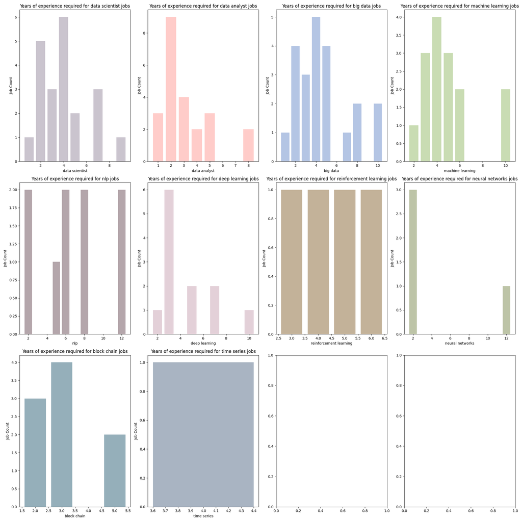

## 6 Topics

Based on class descriptions we have an idea on what could be included in a class, but sometimes that can be very different from the responsabilities that one might have in a job or the qualifications that they might ask us to have. Based on that it was decided that qualifications based on field should be explored a bit further, with the intention of finding similarities of needs between fields that the students could use to get a better understanding.

[figure not shown]

Thanks to these plots we are able to observe the most common words that appear throughout the job listings, with it we are able to observe that jobs wihin different fields have some similarities, but also some differences. Almost all the fields seem to require some sort of problem solving and teamwork, which is something fairly common in data science, however there seems to be some differences as well such as the need for customer service and report in Big Data or a statistical analysis in Machine Learning. Based on the results we can theorize that students with a business side would benefit from taking Big Data as one of their classes while students with a statistics background could take the machine learning elective.

## 7 Salary

The last area we decided to cover was salary, it was an aspect that we were not entirely sure on how to include since it is believed that the prospects of a higher salary should not influence your decision on the class that you take, however it was ultimately decided that it should be included since it is quite an important part of a job listing and something that we look for when applying for jobs. In the graphs below we will observe the distribution of salaries and how each field has different averages.

[figure not shown]

Using this graphs we are able to observe that almost every section has an above average salary for the majority of their listings, but with this in mind it is also worth to note that there are areas that tend to have higher average salaries such as NLP or Machine Learning. Based on the results we obtained we choose to believe that students can observe salaries while thinking about which class to pick, but they should also focus on other areas since all of the fields seem to have high salaries.

## 8 Conclusion

Through a variety of research we have been able to explore different reasons to pick our electives for next semester, taking into consideration important aspects for students such as experience,location, scheduling type or qualifications. Based on our results we are able to confidently say that depending on what the student desires, some of the electives might be more benefitial for them and might open more opportunities for the future in areas they might be interested in.With this in mind we believe that the best approach for a lot of students would be to take some time before choosing their electives to research, as well as spending some time during summer in case they want to make a last minute switch.